# Tutorial for the quality control of climate data with agrometflow

Author

agrometflow

Published

April 2, 2026

## 1 Introduction

This page illustrates how to use the **agrometflow** plotting functions for visual quality control of climate data. These functions are inspired by the R package dataresqc by Yuri Brugnara & Stefan Hunziker.

The functions covered here are:

| Function | Description |
| --- | --- |
| `plot_daily` | Daily time series with missing-data indicators |
| `plot_decimals` | Distribution of decimal digits (reporting resolution) |
| `plot_weekly_cycle` | Wet-day fraction by day of week (data-rescue bias test) |
| `plot_subdaily` | Sub-daily data organized by month |

All functions display inline in Jupyter/Quarto by default (`show=True`) and can optionally save to PDF (`outfile=` or `outpath=`).

## 2 Setup

```python
import pandas as pd
import numpy as np
import matplotlib.pyplot as plt
from pathlib import Path
from agrometflow.dataquality.plots import (
    plot_decimals,
    plot_daily,
    plot_subdaily,
    plot_weekly_cycle
)
```

## 3 Load sample data

We use a daily climate series downloaded from [NASA POWER](https://power.larc.nasa.gov/) for a location in West Africa (lat 12.5°N, lon -1.2°E), covering 1981–2020.

```python
csv_path = Path("data/climate/power/power_19810101_20201231.csv")

clim_df = pd.read_csv(csv_path)
clim_df["Date"] = pd.to_datetime(clim_df["Date"], format="%Y%m%d", errors="coerce")

print(f"Records : {len(clim_df)}")
print(f"Period  : {clim_df['Date'].min().date()} → {clim_df['Date'].max().date()}")
print(f"Columns : {list(clim_df.columns)}")
clim_df.head()
```

```
Records : 14610
Period  : 1981-01-01 → 2020-12-31
Columns : ['Date', 'T2M', 'PR', 'TMIN', 'TMAX', 'lat', 'lon']
```

|  | Date | T2M | PR | TMIN | TMAX | lat | lon |
| --- | --- | --- | --- | --- | --- | --- | --- |
| 0 | 1981-01-01 | 20.17 | 0.0 | 12.58 | 30.38 | 12.5 | -1.2 |
| 1 | 1981-01-02 | 19.59 | 0.0 | 11.99 | 30.16 | 12.5 | -1.2 |
| 2 | 1981-01-03 | 18.53 | 0.0 | 11.05 | 28.55 | 12.5 | -1.2 |
| 3 | 1981-01-04 | 19.11 | 0.0 | 11.84 | 28.83 | 12.5 | -1.2 |
| 4 | 1981-01-05 | 19.46 | 0.0 | 12.48 | 29.25 | 12.5 | -1.2 |

## 4 Daily time series

The function `plot_daily` plots a daily time series with one panel per year (or group of years). Missing dates are marked with red crosses at the bottom of each panel.

### 4.1 One year per panel

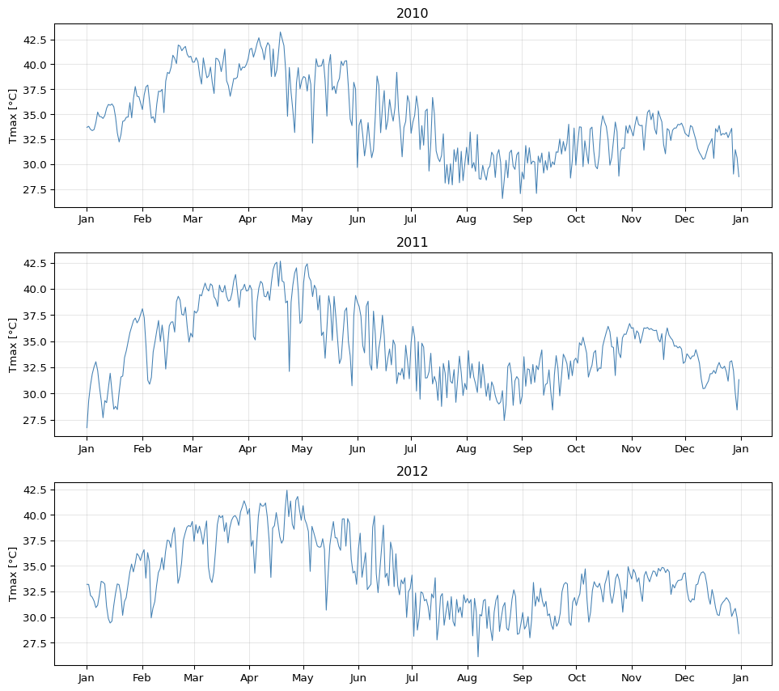

```python
plot_daily(
    data=clim_df[["Date", "TMAX"]].rename(columns={"TMAX": "value"}),
    date_col="Date",
    value_col="value",
    var_name="Tmax",
    units="°C",
    startyear=2010,
    endyear=2012,
    years_per_panel=1,
    show_missing=True,
    show=True,
    color="steelblue",
    linewidth=0.8
)
```

### 4.2 Multiple years per panel

You can group several years in a single panel using `years_per_panel`:

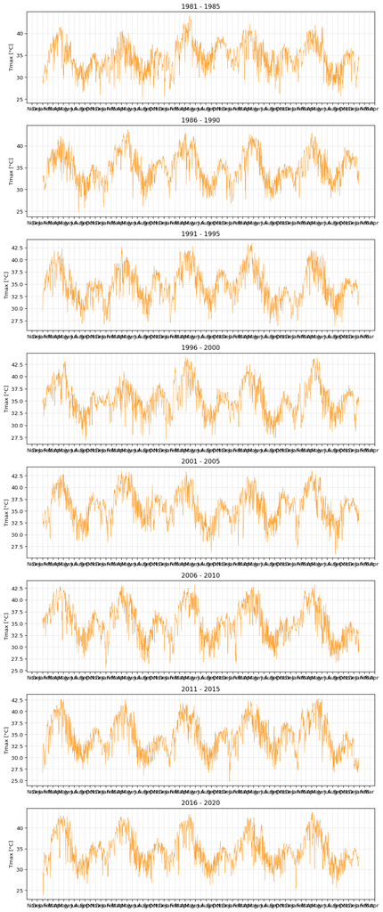

```python
plot_daily(
    data=clim_df[["Date", "TMAX"]].rename(columns={"TMAX": "value"}),
    date_col="Date",
    value_col="value",
    var_name="Tmax",
    units="°C",
    startyear=1981,
    endyear=2020,
    years_per_panel=5,
    show_missing=False,
    show=True,
    color="darkorange",
    linewidth=0.6,
    alpha=0.8
)
```

## 5 Distribution of decimals

The function `plot_decimals` examines the **reporting resolution** of a series by counting how often each decimal digit (0–9) appears in the data.

A uniform distribution across all decimals indicates 0.1-unit precision. Systematic over- or under-representation of certain decimals is a sign of rounding, conversion artefacts, or digitization biases.

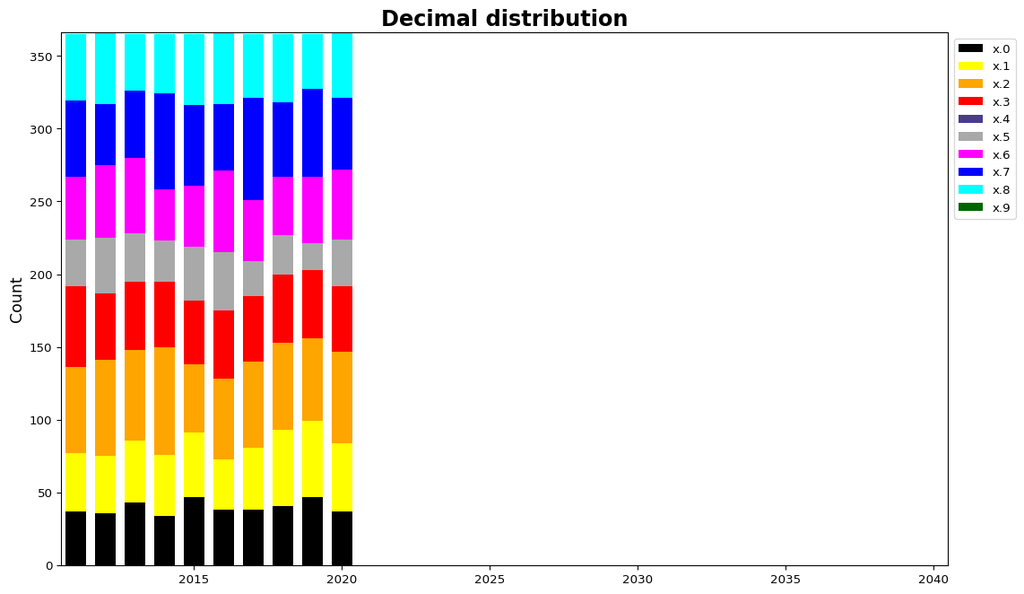

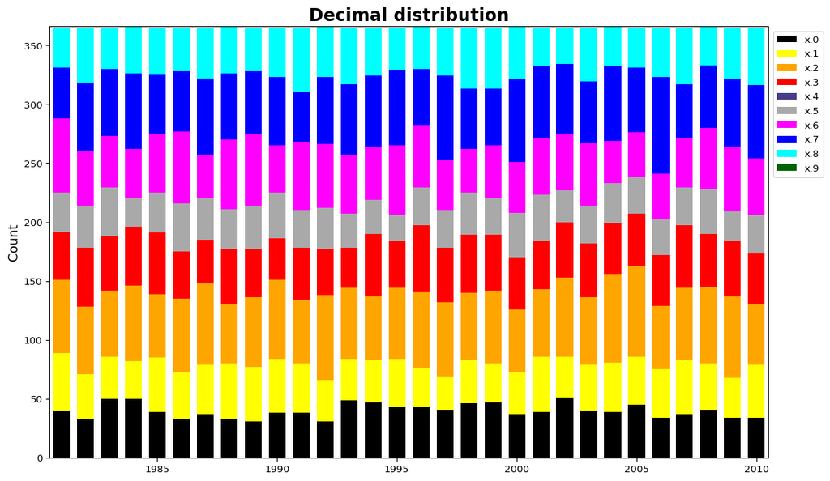

```python
plot_decimals(
    data=clim_df[["Date", "TMAX"]].rename(columns={"TMAX": "value"}),
    date_col="Date",
    value_col="value",
    startyear=1981,
    endyear=2020,
    show=True
)
```

## 6 Weekly cycle in precipitation

The function `plot_weekly_cycle` tests whether wet-day frequency varies systematically by day of week using a **binomial test** (Hunziker et al., 2017).

This is useful for detecting data-rescue biases: if a human observer tended to skip or accumulate observations on certain days of the week, a systematic pattern would appear.

Bars shown in **red** indicate a statistically significant deviation from the overall wet-day probability (dashed line).

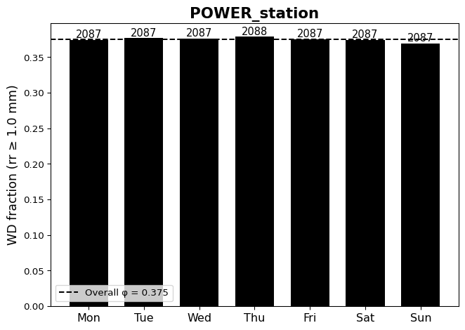

```
Overall wet-day probability φ = 0.375

Significant deviations by day of week:
  None — no significant weekly cycle detected.
```

```python
results = plot_weekly_cycle(
    data=clim_df[["Date", "PR"]].rename(columns={"PR": "rr"}),
    date_col="Date",
    precip_col="rr",
    station_id="POWER_station",
    threshold=1.0,
    confidence_level=0.95,
    show=True
)

print(f"\nOverall wet-day probability φ = {results['phi']:.3f}")
print("\nSignificant deviations by day of week:")
found = False
for wd, sig, frac in zip(results["weekdays"], results["significant"], results["fractions"]):
    if sig:
        direction = "↑" if frac > results["phi"] else "↓"
        print(f"  {wd}: {frac:.3f} {direction}")
        found = True
if not found:
    print("  None — no significant weekly cycle detected.")
```

## 7 Sub-daily data

The function `plot_subdaily` plots sub-daily observations organized by month, with one panel per month (4 × 3 grid). This is useful for inspecting digitized historical sub-daily data for transcription errors, time-of-day biases, or systematic shifts.

Here we illustrate with synthetic hourly temperature data following a realistic annual + diurnal cycle:

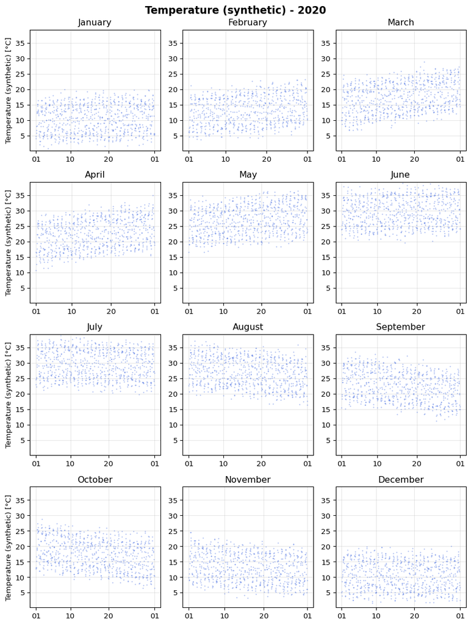

```python
dates = pd.date_range("2020-01-01", "2020-12-31 23:00", freq="h")
np.random.seed(42)
synthetic_temp = (
    20
    + 10 * np.sin(2 * np.pi * np.arange(len(dates)) / (24 * 365) - np.pi / 2)
    +  6 * np.sin(2 * np.pi * np.arange(len(dates)) / 24 - np.pi / 2)
    +  np.random.randn(len(dates)) * 1.5
)

subdaily_df = pd.DataFrame({"datetime": dates, "value": synthetic_temp})

plot_subdaily(
    data=subdaily_df,
    datetime_col="datetime",
    value_col="value",
    var_name="Temperature (synthetic)",
    units="°C",
    year=2020,
    fixed_ylim=True,
    show=True,
    marker=".",
    markersize=1,
    linestyle="",
    alpha=0.5,
    color="royalblue"
)
```

## 8 Save plots to PDF

All functions accept an optional `outfile` (or `outpath` for `plot_weekly_cycle`) parameter to save the plot to a PDF in addition to displaying it.

```
Plot saved in data/qc/decimals_TMAX.pdf
```

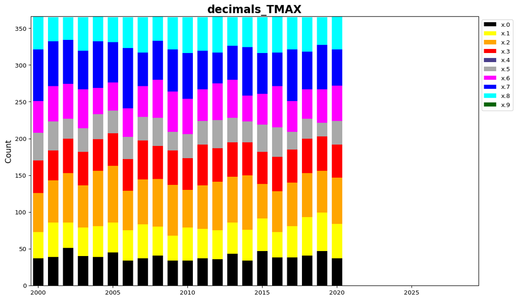

```python
# Example: save decimals plot to PDF and display inline
out_dir = Path("data/qc")
out_dir.mkdir(parents=True, exist_ok=True)

plot_decimals(
    data=clim_df[["Date", "TMAX"]].rename(columns={"TMAX": "value"}),
    date_col="Date",
    value_col="value",
    startyear=2000,
    endyear=2020,
    outfile=out_dir / "decimals_TMAX.pdf",
    show=True
)
```

## 9 GHCN-Daily station data

The `GHCNDDownloader` fetches station observations from the [NOAA GHCN-Daily](https://www.ncei.noaa.gov/products/land-based-station/global-historical-climatology-network-daily) database — the largest archive of daily climate records (~120 000 stations worldwide).

### 9.1 Search available stations

```python
from agrometflow.climate.ghcnd import GHCNDDownloader

dl = GHCNDDownloader(verbose=True)

# Search stations inside a bounding box (West Africa example)
bbox = (-5.0, 10.0, 5.0, 16.0)   # (min_lon, min_lat, max_lon, max_lat)
stations = dl.search_stations(bbox=bbox)
print(f"Stations found: {len(stations)}")
stations.head(10)
```

```
Stations found: 29
```

|  | station_id | lat | lon | elevation | name | country |
| --- | --- | --- | --- | --- | --- | --- |
| 0 | BN000005306 | 11.130 | 2.930 | 290.0 | KANDI | BN |
| 1 | BN000005319 | 10.320 | 1.480 | 460.0 | NATITINGOU | BN |
| 2 | BN000065306 | 11.133 | 2.933 | 292.0 | KANDI | BN |
| 3 | GHM00065401 | 10.900 | -1.100 | 203.0 | NAVRONGO | GH |
| 4 | GHM00065404 | 10.083 | -2.508 | 323.1 | WA | GH |
| 5 | ML000061250 | 15.867 | 2.217 | 278.0 | MENAKA | ML |
| 6 | MLM00061240 | 15.333 | -1.683 | 288.0 | HOMBORI | ML |
| 7 | MLM00061265 | 14.513 | -4.080 | 276.1 | AMBODEDJO | ML |
| 8 | MLM00061277 | 13.333 | -4.833 | 284.0 | SAN | ML |
| 9 | NG000001036 | 14.220 | 1.450 | 209.0 | TILLABERY | NG |

### 9.2 Check variable inventory

Before downloading, inspect which variables and years are available:

```python
inventory = dl.get_inventory()

# Filter to our bounding box stations and core temperature variables
sids = stations["station_id"].tolist()
inv_sub = inventory[
    inventory["station_id"].isin(sids)
    & inventory["variable"].isin(["TMAX", "TMIN", "PRCP"])
].sort_values(["station_id", "variable"])

print(f"Inventory rows: {len(inv_sub)}")
inv_sub.head(15)
```

```
Inventory rows: 87
```

|  | station_id | lat | lon | variable | firstyear | lastyear |
| --- | --- | --- | --- | --- | --- | --- |
| 63648 | BN000005306 | 11.130 | 2.930 | PRCP | 1945 | 1979 |
| 63646 | BN000005306 | 11.130 | 2.930 | TMAX | 1945 | 1979 |
| 63647 | BN000005306 | 11.130 | 2.930 | TMIN | 1945 | 1979 |
| 63651 | BN000005319 | 10.320 | 1.480 | PRCP | 1945 | 2025 |
| 63649 | BN000005319 | 10.320 | 1.480 | TMAX | 1945 | 2025 |
| 63650 | BN000005319 | 10.320 | 1.480 | TMIN | 1945 | 2025 |
| 63665 | BN000065306 | 11.133 | 2.933 | PRCP | 1973 | 2025 |
| 63663 | BN000065306 | 11.133 | 2.933 | TMAX | 1973 | 2025 |
| 63664 | BN000065306 | 11.133 | 2.933 | TMIN | 1973 | 2025 |
| 128934 | GHM00065401 | 10.900 | -1.100 | PRCP | 1973 | 2025 |
| 128932 | GHM00065401 | 10.900 | -1.100 | TMAX | 1973 | 2025 |
| 128933 | GHM00065401 | 10.900 | -1.100 | TMIN | 1973 | 2025 |
| 128938 | GHM00065404 | 10.083 | -2.508 | PRCP | 1973 | 2025 |
| 128936 | GHM00065404 | 10.083 | -2.508 | TMAX | 1973 | 2025 |
| 128937 | GHM00065404 | 10.083 | -2.508 | TMIN | 1973 | 2025 |

### 9.3 Download by station ID

```python
# Pick one station as an example
station_id = stations.iloc[0]["station_id"]
print(f"Downloading station: {station_id}")

dl.download(
    station_ids=[station_id],
    start_date="2000-01-01",
    end_date="2020-12-31",
    variables=["TMAX", "TMIN", "PRCP"],
    output_dir="data/ghcnd",
)

df_station = dl.extract(variables=["TMAX", "TMIN", "PRCP"])
print(f"Records: {len(df_station)}")
df_station.head()
```

### 9.4 Download all stations in a bounding box

```python
dl_bbox = GHCNDDownloader()

dl_bbox.download(
    bbox=bbox,
    start_date="2010-01-01",
    end_date="2020-12-31",
    variables=["TMAX", "TMIN", "PRCP"],
    output_dir="data/ghcnd",
    min_years=5,          # skip stations with < 5 years of overlap
    max_workers=8,
)

df_bbox = dl_bbox.extract(variables=["TMAX", "TMIN", "PRCP"])
print(f"Stations: {df_bbox['station'].nunique()}")
print(f"Records : {len(df_bbox)}")
df_bbox.head()
```

### 9.5 Plot downloaded GHCN-Daily data

Once downloaded, the output CSV can be read back and plotted with the same functions as POWER data:

```python
from pathlib import Path
from agrometflow.climate.ghcnd import GHCNDDownloader
from agrometflow.dataquality.plots import plot_daily, plot_decimals

dl = GHCNDDownloader()
df = dl.extract(source="data/ghcnd/ghcnd_20100101_20201231.csv",
                variables=["TMAX", "TMIN", "PRCP"])

# Plot daily TMAX for first station
sid = df["station"].iloc[0]
df_s = df[df["station"] == sid][["date", "TMAX"]].rename(columns={"TMAX": "value"})

plot_daily(
    data=df_s,
    date_col="date",
    value_col="value",
    var_name=f"Tmax — {sid}",
    units="°C",
    show=True,
    color="tomato",
    linewidth=0.8,
)

plot_decimals(
    data=df_s,
    date_col="date",
    value_col="value",
    show=True,
)
```

### 9.6 Variable reference

| Code | Description | Unit (after conversion) |
| --- | --- | --- |
| `TMAX` | Maximum temperature | °C |
| `TMIN` | Minimum temperature | °C |
| `TAVG` | Average temperature | °C |
| `PRCP` | Precipitation | mm |
| `SNOW` | Snowfall | mm |
| `SNWD` | Snow depth | mm |
| `AWND` | Average wind speed | m/s |

**Tip**

Raw GHCN-Daily values for temperature and precipitation are stored in tenths of the unit. `GHCNDDownloader` divides them by 10 automatically when `convert_units=True` (the default).

## 10 References

- Hunziker, S., et al. (2017). Errors in climate data with emphasis on the European region. *Int. J. Climatol.*, 37, 4131–4145. https://doi.org/10.1002/joc.5001
- Hunziker, S., et al. (2018). Identifying, attributing, and overcoming common data quality issues. *Clim. Past*, 14, 1–20. https://doi.org/10.5194/cp-14-1-2018
- dataresqc R package: https://github.com/c3s-data-rescue-service/dataresqc